# Tema 04 - Análisis Exploratorio de Datos (AED)

Calidad de los datos y descriptiva con propósito

Pedro Albarrán

Dpto. de Fundamentos del Análisis Económico. Universidad de Alicante

Henry Redondo

# El AED: de los datos en bruto a la decisión

## ¿Qué es el AED y para qué sirve?

[figure not shown]

Del fichero recibido a la decisión informada, con dos objetivos:

1. **Conocer los datos y su calidad**: qué mide cada variable, qué falta, qué está mal, qué no es comparable
2. **Describir con propósito**: los patrones que responden a una pregunta económica concreta

**No hay receta**: depende de los datos y del objetivo, y es iterativo.

- **Es un problema económico, más que informático**: una decisión se toma sobre un **número** (un margen, una tasa de paro, un ticket medio), y ese número hereda los defectos de los datos
  - Si el 30% de los clientes insatisfechos no contesta la encuesta, la satisfacción media mide la de quienes contestan
- **Cada decisión de limpieza es un supuesto** sobre cómo se generaron los datos: se escribe, se justifica y se puede deshacer

## Caso del curso: el marketplace *MercadoLocal*

**El negocio**

- Plataforma que conecta pequeños comercios con compradores en el Levante y Madrid
- Dirección quiere responder a tres preguntas:
  1. ¿Cuánto gasta un cliente típico y en qué canal?
  2. ¿Qué vendedores son más productivos?
  3. ¿Crecemos o solo es la campaña de Navidad?

**Tablas disponibles**

- `pedidos_bruto`: una fila por pedido, tal y como sale del sistema
- `vendedores`: una fila por comercio, con datos de un formulario que rellenan ellos mismos
- `serie_ventas`: ventas mensuales agregadas, 2023-2025
- `ventas_prov` y `devoluciones`: resúmenes ya agregados (ventas por provincia; devoluciones por canal y categoría)
- Datos: `marketplace.RData`, en la página Datos. Al final del tema, un caso con datos del INE

**Importante**

El **ejercicio del tema** se hace **durante estas clases**: Tema 04 - Ejercicios del tema. Sus cuatro entregas corresponden a las tres PRÁCTICAS más una con datos del INE.

## Los datos tal y como llegan

```r
pedidos_bruto |> glimpse()
```

| variable | qué debería ser | qué llega |
| --- | --- | --- |
| `fecha` | fecha | texto en DOS formatos distintos |
| `importe` | número (euros) | texto con coma decimal y punto de miles |
| `canal` | factor de 3 niveles | texto con mayúsculas y espacios |
| `cp_envio` | texto de 5 dígitos | número (ha perdido el cero inicial) |
| `valoracion` | 1 a 10, o ausente | incluye el valor centinela `-99` |
| `descuento` | 0 a 1, o “sin promoción” | `NA` con DOS significados distintos |

- Ninguno de estos problemas da un error al importar: el fichero se lee “bien” y todo parece correcto

# Parte I. Detectar los problemas de calidad

## Un protocolo de reconocimiento

- Antes de tocar nada, cuatro preguntas siempre iguales:
  1. **Tamaño y unidad de observación**: ¿cuántas filas y qué es una fila? ¿coincide con lo que esperábamos?
  2. **Tipos**: ¿cada variable tiene el tipo que corresponde a lo que mide?
  3. **Rango y categorías**: ¿los valores son posibles? ¿las categorías son las del diccionario?
  4. **Ausencias**: ¿dónde falta información y por qué?

```r
dim(pedidos_bruto)             # ¿1200 pedidos? ¿o más?
n_distinct(pedidos_bruto$id_pedido)   # ¿la clave identifica las filas?

pedidos_bruto |> count(canal)  # categorías realmente presentes
summary(pedidos_bruto)         # rangos y NAs de las numéricas
modelsummary::datasummary_skim(pedidos_bruto)   # todo de un vistazo
```

- El **diccionario de variables** (qué mide, en qué unidades, qué valores admite) es parte de los datos: si no viene, hay que pedirlo o reconstruirlo
- Hay informes completos automáticos (`DataExplorer::create_report()`): mucho ruido, no conocen el contexto y no distinguen un error de un dato extremo legítimo. La decisión sigue siendo vuestra. Más herramientas, en el anexo

## Problema 1: cada variable, con el tipo de lo que mide

- El tipo lo decide **lo que mide** la variable, no cómo se ha leído:
  - **Cantidades** → número. `importe` llega como texto con formato español (`"1.234,56"`): no da error, pero no se puede sumar
  - **Códigos e identificadores** → texto. `cp_envio` llega como número y pierde el cero (3003 por “03003”); su media no tiene sentido
  - **Categorías** → factor, vengan como texto (`canal`, `sector`) o como números (en la EPA, `SEXO1` vale 1 o 6). Se convierten después de corregir sus erratas (Problema 3)
  - **Fechas** → fecha (Problema 2)

```r
pedidos <- pedidos_bruto |>
  mutate(importe  = parse_number(importe, locale = locale(decimal_mark = ",")),
         cp_envio = str_pad(cp_envio, 5, pad = "0"))     # 3003 -> "03003"
```

## Problema 2: fechas

- Una fecha en texto se ordena alfabéticamente: `"04/03/2025"` va antes que `"12/01/2024"`
- El riesgo real es la **ambigüedad**: `03/04/2025` es 3 de abril en España y 4 de marzo en EE.UU.

```r
pedidos_bruto |> count(str_detect(fecha, "/"))   # ¿cuántos de cada formato?
```

- Con dos formatos mezclados, `parse_date_time()` (del paquete `lubridate`, que viene con el `tidyverse`) prueba los órdenes que le digamos: día-mes-año y año-mes-día

```r
pedidos <- pedidos |>
  mutate(fecha = as_date(parse_date_time(fecha, orders = c("dmy", "ymd"))))

sum(is.na(pedidos$fecha))     # comprobación: ninguna fecha sin convertir
```

- Comprobar siempre el **rango**: fechas anteriores al inicio del negocio o posteriores a hoy son errores

```r
range(pedidos$fecha)
```

## Problema 3: categorías con erratas

- Las mismas categorías escritas de formas distintas se cuentan como distintas: el `group_by()` del Tema 03 obedece al texto, no a la intención

```r
pedidos |> count(canal)              # "web", "WEB", " web ", ...
vendedores |> count(provincia)       # "Valencia" y "València"
```

- Homogeneizar es una **decisión**: estamos afirmando que dos etiquetas son la misma cosa

```r
pedidos <- pedidos |>
  mutate(canal = str_trim(str_to_lower(canal)),
         canal = parse_factor(canal, levels = c("web", "app", "tienda")))

vendedores <- vendedores |>
  mutate(provincia = str_trim(str_to_title(provincia)),
         provincia = fct_recode(provincia, "Valencia" = "València"))
```

- Después, **volver a contar**: si aparece un nivel `NA`, es que había una categoría que no estaba en nuestra lista. Ya limpias, las demás categorías pasan a factor, varias a la vez con `across()` (Tema 03)

```r
pedidos |> count(canal)
vendedores <- vendedores |> mutate(across(c(provincia, sector), as.factor))
```

## Problema 4: unidades mezcladas

- Los vendedores rellenan su facturación anual en un formulario libre: unos ponen euros y otros miles de euros. Cada fila está medida en una escala distinta
- Detectar
- Decidir

```r
summary(vendedores$facturacion_anual)

ggplot(vendedores, aes(x = facturacion_anual)) +
  geom_histogram(bins = 30) + scale_x_log10()

vendedores |> mutate(fact_por_empleado = facturacion_anual / empleados) |>
  arrange(fact_por_empleado) |> head(5)
```

- Por **órdenes de magnitud** y, mejor, contrastando con una variable relacionada: 200 euros por empleado y año es económicamente imposible. Es otra unidad
- La corrección necesita una **regla** escrita, no un ojo clínico

```r
vendedores <- vendedores |>
  mutate(
    # regla: una facturación por empleado por debajo de 5.000 euros al año
    # es imposible en este sector; esa fila estaba declarada en miles
    fact_empleado = facturacion_anual / empleados,
    facturacion_eur = if_else(fact_empleado < 5000,       # if_else(condición,
                              facturacion_anual * 1000,   #   si se cumple,
                              facturacion_anual)          #   si no)
  )

vendedores |> summarize(min = min(facturacion_eur / empleados),
                        max = max(facturacion_eur / empleados))
```

- El umbral es un supuesto: hay que escribirlo, y comprobar que ningún caso queda cerca del corte

## Problema 5: duplicados

- Hay dos tipos y no significan lo mismo
  1. **Filas idénticas**: casi siempre un fallo de exportación o de carga
  2. **Clave repetida con contenido distinto**: dos versiones del mismo hecho

```r
sum(duplicated(pedidos))                       # filas completas repetidas

pedidos |> count(id_pedido) |> filter(n > 1)   # clave repetida
```

- Antes de borrar, hay que **mirar** las filas en conflicto: en nuestro caso, el mismo pedido aparece con y sin IVA

```r
pedidos |> group_by(id_pedido) |> filter(n() > 1) |>
  arrange(id_pedido) |> select(id_pedido, fecha, importe)
```

- Los 23 registros repetidos son menos del 2% de las filas: inflan los ingresos sin que nada falle

## Problema 6: dónde falta información

- `summary()` dice cuántos ausentes hay en cada variable numérica (`NA's`)

```r
summary(pedidos)
# todas las columnas, también las de texto
pedidos |> summarize(across(everything(), ~ sum(is.na(.x))))
```

- Y deja ver los ausentes **disfrazados**: códigos centinela que R lee como números válidos. El mínimo de `valoracion` es `-99`, en una escala de 1 a 10
- Un `-99` no declarado contamina toda la descriptiva: entra en la media, en la desviación típica y en el gráfico

```r
pedidos <- pedidos |> mutate(valoracion = na_if(valoracion, -99))
```

## PRÁCTICA en clase (1): auditoría de calidad

Trabajad con `pedidos_bruto` y `vendedores`. En 25 minutos, y **sin corregir nada todavía**, elaborad un informe de una página con:

1. Número de filas y comprobación de si `id_pedido` identifica de forma única cada pedido
2. Lista de variables cuyo tipo NO corresponde a lo que miden, con el problema concreto de cada una
3. Recuento de las categorías realmente presentes en `canal` y en `provincia`, señalando cuáles son la misma cosa
4. Número de ausentes por variable, distinguiendo los `NA` de los códigos centinela
5. Para CADA problema detectado, una frase: qué cifra del informe final quedaría mal si no lo corregimos

**Nota**

**Ahora el ejercicio 1**, los cinco apartados: es esta misma auditoría, apartado por apartado.

# Parte I (b). Decidir qué hacer

## Ausentes: por qué faltan

- Contarlos es el primer paso. Lo que decide qué hacer con ellos es **por qué** faltan. Tres mecanismos:
  1. **Por azar**: un fallo del servidor un martes. Quedarse con los casos completos solo reduce la muestra
  2. **Según algo que observamos**: los clientes de más edad contestan menos las encuestas por la app. Se corrige condicionando en esa variable (comparando dentro de cada grupo de edad)
  3. **Según el propio valor que falta**: el cliente enfadado no contesta la encuesta. La valoración media observada mide la satisfacción **de los que contestan**

## Ausentes: ¿y qué hacemos?

- Primero, el **ausente estructural**: `descuento = NA` significa “sin promoción”. El valor correcto es 0

```r
pedidos <- pedidos |> mutate(descuento = replace_na(descuento, 0))
```

- Para los ausentes de verdad (`valoracion`), tres opciones:
- 1. Eliminar
- 2. Imputar
- 3. Indicador de ausencia
- `drop_na()`: válido si la ausencia es por azar. Si depende del valor, se elimina justo al cliente que interesa (el enfadado)
- Sustituir el `NA` por un valor estimado. Mantiene el tamaño muestral, pero inventa variación: la dispersión sale menor que la real
- Con la **media (o mediana) de todos**: a quien calla se le asigna la nota de los que hablan. Si los que callan son distintos en todo lo demás, es la peor opción
- Con la **media condicional**: la de los clientes parecidos (mismo canal, misma categoría). Es la idea de la regresión (Tema 05)
- Guardar quién no contesta y analizarlo. El sesgo sigue ahí, pero a la vista: ¿gastan distinto?, ¿devuelven más?

```r
pedidos <- pedidos |> mutate(sin_valoracion = is.na(valoracion))

pedidos |> group_by(sin_valoracion) |>
  summarize(n = n(), importe_medio = mean(importe),
            tasa_devol = mean(devuelto))
```

## Atípicos: detectar

- Un valor atípico es el que queda lejos del resto. Atípico **no** significa malo ni erróneo
- **No hay una regla aceptada** para detectarlos. El diagrama de caja aplica una **convención**: más de 1,5 veces el rango intercuartílico por debajo de Q<sub>1</sub> o por encima de Q<sub>3</sub>

```r
ggplot(pedidos, aes(y = importe)) + geom_boxplot()
```

- Otras convenciones son igual de defendibles: el 5% (o el 1%) de cada cola, o más de tres desviaciones típicas de la media
- Aquí la del diagrama de caja marca 77 pedidos, más del 6% de la muestra. Con asimetría (renta, ventas, tamaño de empresa) esa convención señala como atípica una cola derecha normal

## Atípicos: decidir

- Dos tipos:
  1. **Errores en los datos** (una coma mal puesta): detectarlos, entender por qué, y corregirlos o eliminarlos documentándolo
  2. **Valores legítimos**: de la misma población (un mayorista), eliminarlos destruye información; de otra población (un cliente B2B entre minoristas), se analizan aparte
- ¿Cuándo es uno y cuándo otro? **No hay regla mecánica**: hay que entender los datos y saber de qué van. La IA tampoco lo resuelve, porque no sabe cómo se generaron

```r
pedidos |> arrange(desc(importe)) |>
  select(id_pedido, canal, unidades, importe) |> head(6)
```

- 4.729 euros con 3 unidades: coma mal puesta. 4.974 euros con 90 unidades: mayorista
- Si se conservan: analizar en logaritmos, usar la mediana, o **winsorizar** (sustituir los valores que pasan el umbral usado para detectarlos por el propio umbral), declarándolo

## PRÁCTICA en clase (2): limpiar y justificar

Sobre la auditoría de la práctica anterior, en 30 minutos:

1. Escribid un único bloque de limpieza que corrija tipos, categorías y ausentes centinela, y elimine los duplicados exactos
2. Comprobad el resultado: filas antes y después, tipos, recuento de `canal` y rango de `fecha`
3. Calculad los **ingresos totales** y el **ticket medio** antes y después de eliminar los duplicados exactos. ¿En cuántos euros y en qué porcentaje cambia la cifra que iría al informe?
4. Decidid qué hacer con los 8 pedidos de clave repetida y **justificad la decisión en dos frases**
5. Elegid un pedido atípico y argumentad si es error, cliente mayorista u otra población, usando `unidades` como apoyo

**Nota**

**Ahora el ejercicio 2.** Los apartados a) a e) son esta práctica; f) y g) van un paso más allá, con la columna que viene dada y con la identidad que tiene que cumplirse.

## Un flujo de limpieza reproducible (puesta en común)

- Los datos en bruto **no se tocan nunca**: la limpieza es un script que va del fichero original al fichero de trabajo

```r
pedidos_limpio <- pedidos_bruto |>
  # 1. tipos
  mutate(importe  = parse_number(importe, locale = locale(decimal_mark = ",")),
         cp_envio = str_pad(cp_envio, 5, pad = "0"),
         fecha    = as_date(parse_date_time(fecha, c("dmy", "ymd")))) |>
  # 2. categorías
  mutate(canal = parse_factor(str_trim(str_to_lower(canal)),
                              levels = c("web", "app", "tienda"))) |>
  # 3. ausentes: centinela y estructural
  mutate(valoracion = na_if(valoracion, -99),
         descuento  = replace_na(descuento, 0)) |>
  # 4. duplicados exactos
  distinct()
```

- Cada bloque lleva un comentario con la **decisión** y su motivo; el número de filas se comprueba antes y después

```r
nrow(pedidos_bruto); nrow(pedidos_limpio)
```

# Parte II. Descriptiva con propósito

## No describir por describir

- El orden es siempre el mismo:

  **pregunta económica** → **magnitud que la responde** → **estadístico o gráfico** → **lectura**
- Ejemplos con nuestro caso:

| Pregunta de dirección | Magnitud que la responde |
| --- | --- |
| ¿Cuánto gasta un cliente típico? | centro de una distribución asimétrica |
| ¿La app canibaliza la web o amplía el mercado? | gasto por cliente y solapamiento |
| ¿Qué vendedores son más productivos? | ventas por empleado |
| ¿Crecemos? | variación interanual |

- El estadístico o el gráfico dependen del tipo de variables: es lo que viene ahora. Y si no sabéis qué decisión cambia con el resultado, sobra

## Análisis de variación: qué mirar

- La **variación** de una variable es su **distribución**. Lo que aparezca aquí puede obligar a volver a limpiar. Qué buscar:
  - **Inconsistencias**: categorías imposibles (“desconocido”, “otros” que lo son todo), valores fuera de rango
  - **Valores frecuentes**: ceros, números redondos, repeticiones. ¿Por qué? Muchas empresas con 49 empleados: el umbral de pequeña empresa es 50
  - **Categorías**: ¿tienen sentido? ¿Conviene agrupar las que tienen pocas observaciones o se comportan igual?
  - **Variables continuas**: asimetría (logaritmos) y si conviene **discretizarlas** en tramos (grupos de edad, tramos de renta)

```r
pedidos |> mutate(tramo = cut(importe, breaks = c(0, 20, 50, 100, Inf))) |>
  count(tramo)
```

## Análisis de variación: según el tipo de variable

- El **tipo de variable** decide la tabla, el gráfico y el resumen

| Variable | Tabla | Gráfico | Resumen |
| --- | --- | --- | --- |
| Cualitativa (`canal`) | frecuencias y proporciones (`count()`) | barras (`geom_bar()`) | moda, proporciones |
| Cuantitativa (`importe`) | estadísticos de centro, dispersión y posición | histograma, densidad, caja | media, mediana, desviación típica, cuartiles |

```r
pedidos |> count(canal) |> mutate(prop = n / sum(n))
# agrupar categorías pequeñas
vendedores |>
  mutate(provincia = fct_lump_min(provincia, min = 10,
                                  other_level = "Otras")) |>
  count(provincia)

pedidos |> summarize(media = mean(importe), mediana = median(importe),
                     de = sd(importe), p25 = quantile(importe, 0.25),
                     p75 = quantile(importe, 0.75))
```

- Con distribuciones asimétricas, media y mediana responden a preguntas distintas: la **media**, cuánto se factura por pedido (media × n = total); la **mediana**, cuánto gasta un cliente típico

## Análisis de covariación: ¿están relacionadas?

- Ahora la pregunta es si hay **evidencia en los datos** de que dos variables están relacionadas: si saber el valor de una cambia lo que esperamos de la otra
- La herramienta es la **distribución condicional** de $Y$ dado $X$, $\Pr(Y \mid X = x)$:
  - si es la misma para cualquier valor $x$, no hay relación
  - si cambia con $x$, la hay
- ¿Se devuelve igual en todos los canales?

| canal | pedidos | devueltos | % devueltos |
| --- | --- | --- | --- |
| web | 557 | 41 | 7,4% |
| app | 468 | 57 | 12,2% |
| tienda | 183 | 5 | 2,7% |

- La proporción de devoluciones cambia con el canal: es evidencia de relación
  - Se comparan proporciones dentro de cada canal: cada canal tiene un número distinto de pedidos
  - Si la distribución de $Y$ cambia con $X$, conocer $X$ ayuda a **predecir** $Y$: su media condicional $E[Y \mid X]$

## Análisis de covariación: según el tipo de variables

- Lo que se compara es siempre la distribución de $Y$ en cada valor de $X$. La herramienta depende de los tipos:

| Variables | Qué se compara | Estadísticos | Gráfico |
| --- | --- | --- | --- |
| Dos cualitativas (`devuelto`, `canal`) | las proporciones de $Y$ en cada categoría de $X$ | tabla de contingencia, proporciones por fila | barras al 100% |
| Cuantitativa y cualitativa (`importe`, `canal`) | la distribución de $Y$ en cada grupo | media, mediana y dispersión por grupo | cajas por grupo, densidades superpuestas |
| Dos cuantitativas (`importe`, `unidades`) | cómo cambia $Y$ al cambiar $X$ | correlación | dispersión con su curva |

- La **regresión** sirve en los tres casos: estima la media condicional $E[Y \mid X]$, sea $X$ cualitativa o cuantitativa (Tema 05). La **correlación** solo existe entre dos cuantitativas
- Antes de comparar grupos: **cuántas observaciones hay en cada uno**. Una media sobre 7 pedidos no se compara con una sobre 700

## Dos cuantitativas: la correlación

- La **correlación** mide la asociación **lineal** entre dos variables cuantitativas, entre -1 y 1
- Con varias variables se mira la **matriz de correlaciones**, mejor en un gráfico
- `unidades` e `importe`: 0,58. En logaritmos baja a 0,15: la arrastran unos pocos pedidos enormes. Es sensible a los atípicos
- La curva de `geom_smooth()` es la media condicional $E[Y \mid X]$; con `method = "lm"`, la recta de la regresión

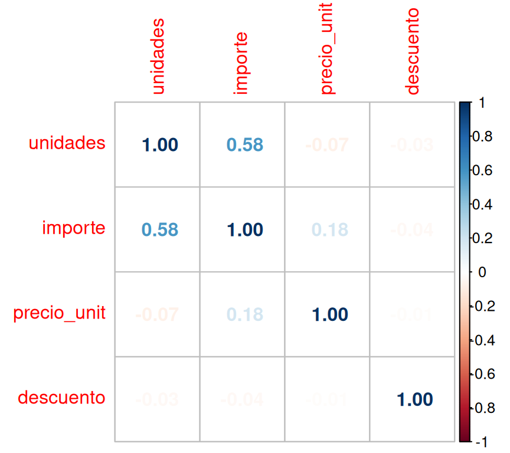

```r
m <- pedidos |>
  select(unidades, importe,
         precio_unit, descuento) |>
  cor()
corrplot::corrplot(m, "number")
```

## Covariación: el código

- Dos cualitativas
- Cuantitativa y cualitativa
- Dos cuantitativas

```r
pedidos |> count(canal, devuelto) |>
  group_by(canal) |> mutate(prop = n / sum(n))

pedidos |> count(canal, devuelto) |>
  ggplot(aes(x = canal, y = n, fill = devuelto)) +
  geom_col(position = "fill")

lm(devuelto ~ canal, data = pedidos)   # las mismas proporciones
```

**Importante**

Hasta ahora `geom_bar()` contaba él solo las observaciones de cada categoría. Aquí la altura ya la hemos calculado con `count()`, así que hay que decirle que **no vuelva a contar**: `geom_bar(stat = "identity")`, y `geom_col()` es su atajo.

```r
pedidos |> group_by(canal) |>
  summarize(n = n(), media = mean(importe), mediana = median(importe))

ggplot(pedidos, aes(x = canal, y = importe)) +
  geom_boxplot() + scale_y_log10()
ggplot(pedidos, aes(x = importe, colour = canal)) +
  geom_density() + scale_x_log10()

lm(importe ~ canal, data = pedidos)    # las mismas medias por canal
```

```r
pedidos |> select(unidades, importe, descuento) |> cor()

ggplot(pedidos, aes(x = unidades, y = importe)) +
  geom_point(alpha = 0.3) + geom_smooth()

lm(importe ~ unidades, data = pedidos)  # la recta
```

# Parte II (b). KPIs y sus trampas

## Qué es un buen indicador (KPI)

- Un KPI es un número que resume el estado del negocio y sobre el que **alguien decide**
- Para que sirva necesita cuatro cosas, y las cuatro se olvidan a menudo:
  1. **Definición escrita**: ¿“cliente activo” es quien compró alguna vez, en el último año o en el último mes?
  2. **Denominador explícito**: por pedido, por cliente, por empleado, por euro invertido
  3. **Frecuencia y periodo de comparación**: mensual frente al mes anterior no es lo mismo que frente al mismo mes del año pasado
  4. **Responsable**: quién puede actuar sobre él

```r
kpis <- pedidos |>
  summarize(pedidos          = n(),
            ingresos         = sum(importe),
            ticket_mediano   = median(importe),
            clientes_activos = n_distinct(id_cliente),
            tasa_devolucion  = mean(devuelto))
```

## Trampa 1: niveles y tasas

- El nivel y la tasa responden a preguntas distintas y con frecuencia se contradicen

```r
ventas_prov |>
  mutate(variacion_abs = ventas_2025 - ventas_2024,
         variacion_pct = (ventas_2025 / ventas_2024 - 1) * 100) |>
  arrange(desc(variacion_pct))
```

| provincia | ventas 2024 | ventas 2025 | variación absoluta | variación % |
| --- | --- | --- | --- | --- |
| Teruel | 4.000 | 10.000 | +6.000 | +150,0% |
| Alicante | 412.000 | 445.000 | +33.000 | +8,0% |
| Valencia | 380.000 | 399.000 | +19.000 | +5,0% |
| Madrid | 915.000 | 951.000 | +36.000 | +3,9% |

- Teruel encabeza el crecimiento porcentual y aporta el 6% del aumento total. Madrid es el último en porcentaje y el primero en euros
- Un porcentaje sobre una base pequeña es ruido: mostrad siempre el nivel al lado

## Trampa 2: promedios de promedios

- La media de unas medias solo coincide con la media global si todos los grupos tienen el mismo tamaño

```r
por_vendedor <- pedidos |> group_by(id_vendedor) |>
  summarize(ticket_medio = mean(importe), n = n())

por_vendedor |> summarize(media_de_medias = mean(ticket_medio))
pedidos |> summarize(media_global = mean(importe))
```

- La media de medias da a un vendedor con 3 pedidos el mismo peso que a otro con 90
- Para agregar tasas hay que **ponderar por el denominador**, o mejor: sumar numeradores y denominadores

```r
pedidos |> summarize(tasa_correcta = sum(devuelto) / n())

pedidos |> group_by(canal) |> summarize(tasa = mean(devuelto)) |>
  summarize(tasa_incorrecta = mean(tasa))
```

- Lo mismo ocurre con la tasa de paro nacional: no es la media de las tasas de las comunidades, sino el cociente de la suma de parados entre la suma de activos

## Trampa 3: la agregación puede invertir el resultado

- Tasa de devolución por canal, dentro de cada categoría de producto y en el total:

| categoría | canal | pedidos | devueltos | tasa |
| --- | --- | --- | --- | --- |
| Electrónica | web | 200 | 20 | 10,0% |
| Electrónica | app | 800 | 96 | 12,0% |
| Textil | web | 800 | 240 | 30,0% |
| Textil | app | 200 | 64 | 32,0% |
| **Total** | web | 1.000 | 260 | **26,0%** |
| **Total** | app | 1.000 | 160 | **16,0%** |

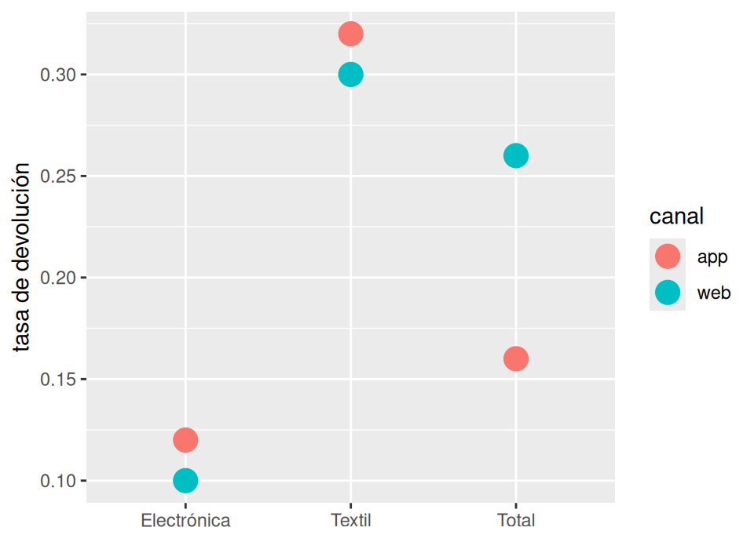

```r
devoluciones |> group_by(canal) |>
  summarize(tasa_total = sum(devueltos) / sum(pedidos))
```

- **Paradoja de Simpson**: la app devuelve más en cada categoría y menos en el total. La causa es la **composición**: la app vende sobre todo electrónica, que se devuelve poco
- Qué hacer: comparar **dentro** de grupos homogéneos. Es lo que hace una regresión que incluye la categoría (Tema 05)

## Trampa 4: estacionalidad y elección del periodo

- Muchas series económicas tienen un patrón que se repite cada año: comercio en diciembre, hostelería en verano, empleo agrario por campañas

```r
ggplot(serie_ventas, aes(x = mes, y = ventas)) + geom_line()
```

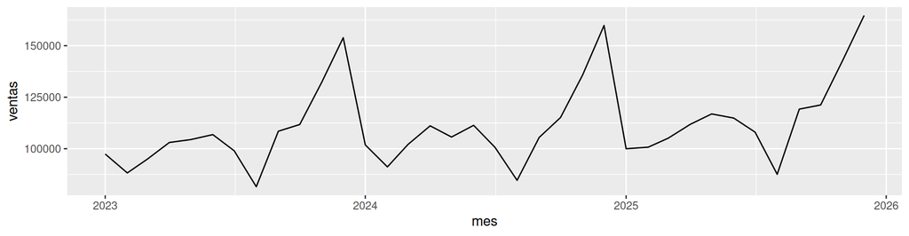

- Comparar diciembre con noviembre mide la Navidad, y poco del negocio

```r
serie_ventas |>
  # lag(x, k): el valor de k meses antes
  mutate(var_mensual   = ventas / lag(ventas, 1)  - 1,
         var_interanual = ventas / lag(ventas, 12) - 1) |>
  filter(!is.na(var_interanual))
```

## PRÁCTICA en clase (3): un cuadro de mando honesto

Dirección pide **cinco** indicadores para la reunión mensual. En 30 minutos, sobre `pedidos_limpio` y `serie_ventas`:

1. Elegid los cinco KPI y escribid la definición exacta de cada uno (numerador, denominador, periodo)
2. Calculadlos con `summarize()` y presentadlos en una tabla
3. Para el gasto por cliente, decidid si dais media o mediana y **justificadlo** con la forma de la distribución
4. Añadid la variación interanual de ventas del último mes, no la mensual, y explicad en una frase por qué
5. Escribid al pie del cuadro **una advertencia** sobre la trampa que más amenaza a vuestros indicadores (composición, base pequeña, estacionalidad o selección en las valoraciones)

**Nota**

**Ahora el ejercicio 3.** Los apartados a), b), c), g) y h) son esta práctica; d), e) y f) son las tres trampas de estas transparencias: los promedios de promedios, la agregación que invierte el resultado y la base pequeña.

# Un caso con datos del INE

## Datos oficiales: la pregunta y la fuente

- Muchas preguntas solo se responden con estadística oficial: **INE**, **Eurostat**, **Banco de España**, **OCDE**, Banco Mundial… Todas publican sus tablas para descargar en CSV
- La nuestra: **¿ha subido la cesta de la compra más que el resto de los precios?** Hace falta la variación anual del IPC general y la de alimentos, en un periodo largo
- Cada tabla de INEbase se descarga en CSV desde su página, y esa dirección se lee directamente desde R:

```r
ipc <- read_csv2("https://www.ine.es/jaxiT3/files/t/es/csv_bdsc/50902.csv")

ipc |> count(`Tipo de dato`)
ipc |> distinct(Periodo) |> head(3)    # "2025M12": año, M y mes
```

- `read_csv2()` es `read_csv()` para el formato español: separador `;` y coma decimal. Los nombres con espacios van entre comillas invertidas: `` `Tipo de dato` ``
- 50902 identifica la tabla (IPC nacional, general y grupos): comprobad en la web qué contiene. Viene ordenada, una fila por grupo, tipo de dato y periodo. La API del INE, en el anexo

## Del CSV al gráfico

- Variación anual del índice general y de alimentos, con el periodo convertido en fecha

```r
ipc <- ipc |>
  filter(`Tipo de dato` == "Variación anual",
         `Grupos ECOICOP` %in% c("Índice general",
                                 "01 Alimentos y bebidas no alcohólicas")) |>
  mutate(fecha = ym(Periodo))       # "2025M12" -> fecha (lubridate)

ggplot(ipc, aes(x = fecha, y = Total, color = `Grupos ECOICOP`)) +
  geom_line() + geom_hline(yintercept = 0)
```

- Enero de 2023: índice general 5,9%, alimentos 15,4%

## Qué comprobar antes de creerse el resultado

- Un dato oficial también exige AED:
  1. **Cuántas series han llegado**, y si son las pedidas
  2. **Huecos** y valores provisionales
  3. **Base del índice**: se comparan variaciones, no niveles de bases distintas
  4. **Ponderaciones**: la cesta del IPC cambia cada año
- La lectura económica: si alimentación sube más que el general, el encarecimiento golpea más a los hogares de renta baja, que dedican a comer una parte mayor de su gasto. Un índice medio lo esconde

**Nota**

**Ahora el ejercicio 4**: la EPA, con la tabla 65335 del INE.

# Microdatos: los datos de los que salen las tablas

## Las tablas publicadas salen de aquí

- Las tablas del INE son un **menú cerrado**: paro por sexo y comunidad, sí; paro según la situación de la pareja, no
- Todas se calculan con el mismo fichero: **una fila por persona entrevistada**, los *microdatos*. Con él se puede:
  1. **Reproducir** cualquier tabla publicada
  2. Construir el **cruce que nadie publicó**
  3. Estimar **modelos a nivel individual**
- El precio: los conceptos (ocupado, parado) no vienen calculados. Los construís vosotros

## Bajároslo vosotros es parte del trabajo

- Los microdatos de la EPA están en el ftp del INE: `datos_2t26.zip` (segundo trimestre de 2026, 21 MB) y el **diseño de registro**, `dr_EPA_2026.xlsx`, que dice qué significa cada columna y cada código
- El código, en la carpeta del proyecto; lo descargado, en una subcarpeta `datos`:

```
epa/
├── analisis-epa.qmd
└── datos/      (datos_2t26.zip, dr_EPA_2026.xlsx, CSV/EPA_2026T2.tab)
```

```r
url <- "https://www.ine.es/ftp/microdatos/epa/datos_2t26.zip"
download.file(url, "datos/datos_2t26.zip")   # basta una vez
unzip("datos/datos_2t26.zip", files = "CSV/EPA_2026T2.tab", exdir = "datos")

epa <- read_delim("datos/CSV/EPA_2026T2.tab", delim = "\t",
                  col_types = cols(.default = col_character()))
```

- `download.file()` guarda en disco lo que hay en una dirección web. `unzip()` extrae del zip solo el fichero indicado (`files`) en la carpeta indicada (`exdir`)
- `read_delim()` lee texto con el separador que se le diga (`"\t"` es el tabulador). Con `col_types` se lee todo como texto, porque los códigos del INE **son** texto: `"03"` es un código. Otros formatos del zip, en el anexo

## Qué es una fila

- El fichero trae **114.021 personas** y 94 variables. Las que vamos a usar:

| Variable | Qué es |
| --- | --- |
| `NVIVI`, `NPERS` | vivienda y orden de la persona dentro de ella (47.914 hogares) |
| `RELPP1`, `NCONY` | relación con la persona de referencia y orden de su cónyuge |
| `AOI` | situación laboral codificada (la variable clave) |
| `FACTOREL` | factor de elevación: a cuántas personas de la población representa la fila |

- Para pasar a hogares basta un `group_by(NVIVI)` del Tema 03

## Primera trampa: un vacío que significa “no aplica”

- `AOI` está vacía para los menores de 16 años: al leer el texto llega como `NA`

```r
epa |> count(AOI)          # "03" ... "09" y 15.850 NA
```

- Esos `NA` son **estructurales**, como el descuento de la Parte I: la pregunta no se les hace. Se excluyen de la población de 16 y más años, sin imputar nada
- Y `filter()` descarta los `NA` sin avisar: cualquier condición sobre `AOI` deja fuera a los menores aunque no se haya pedido. Mejor decirlo explícitamente

## Segunda: las categorías no son las que parecen

- `AOI` no es “0 = parado, 1 = ocupado”. Hay que leer el diseño de registro:

| Código | Significado |
| --- | --- |
| 03, 04 | **ocupados** (03 son ocupados subempleados) |
| 05, 06 | **parados** (05 busca su primer empleo) |
| 07, 08, 09 | inactivos |

```r
epa <- epa |> mutate(
                     situacion = case_when(AOI %in% c("03", "04") ~ "ocupado",
                                           AOI %in% c("05", "06") ~ "parado",
                                           AOI %in% c("07", "08", "09") ~ "inactivo",
                                           TRUE ~ "menor de 16"))
```

- Quien usa solo el `06` como paro deja fuera a quien busca su primer empleo, que son justo los jóvenes: la tasa nacional baja de **9,873% a 8,757%**. Un punto entero de paro por no leer una tabla de códigos de siete líneas

## Tercera: replicar una cifra publicada

```r
epa <- epa |> mutate(FACTOREL = as.numeric(FACTOREL))
activos <- epa |> filter(situacion %in% c("ocupado", "parado"))

activos |> summarise(
  paro_mal  = 100 * mean(situacion == "parado"),
  paro_bien = 100 * sum(FACTOREL[situacion == "parado"]) / sum(FACTOREL))
```

| Fichero completo | Sin ponderar | Ponderando |
| --- | --- | --- |
| Tasa de paro | 9,499% | **9,873%** |

- Para una cifra representativa de la población hay que ponderar con `FACTOREL`. El INE publica **9,87%** para ese trimestre ([tabla 65335](https://www.ine.es/jaxiT3/Tabla.htm?t=65335)): coincide, y es la prueba de que hemos entendido el fichero
- **Regla: primero se replica una cifra publicada, y solo después se calcula lo que no está publicado**

## La tabla que nadie publica

- Ya podemos contestar lo que no está en ninguna tabla: **¿cómo es el paro de una persona según la situación de su pareja?**
- Cada fila trae en `NCONY` el orden de su cónyuge dentro del hogar, así que hay que **unir el fichero consigo mismo**

```r
parejas <- epa |>
  filter(NCONY != "00") |>                  # "00": sin cónyuge en el hogar
  left_join(epa |> select(NVIVI, NPERS, situacion_pareja = situacion),
            by = c("NVIVI", "NCONY" = "NPERS"))
```

| Situación de la pareja | Tasa de paro de la persona | n |
| --- | --- | --- |
| pareja ocupada | 6,00% | 26.046 |
| pareja parada | **21,04%** | 1.842 |

- Tres veces y media más de paro cuando la pareja también está parada. Importa porque el paro **se concentra en los mismos hogares**: no hay una segunda renta que amortigüe

## Y lo que ninguna tabla puede dar: un modelo

- La tabla anterior ya es un modelo lineal, con una sola variable: $\text{parado}_i = \beta_0 + \beta_1\, \text{pareja parada}_i + u_i$

```r
lm(parado ~ pareja_parada, data = activos_con_pareja, weights = FACTOREL)
```

- $\hat\beta_0 = 0{,}0600$ es la tasa con la pareja ocupada (6,00%) y $\hat\beta_1 = 0{,}1504$ la diferencia: 6,00 + 15,04 = 21,04%. Como `parado` vale 1 o 0, $\beta_1$ es una diferencia de probabilidades
- ¿Sigue ahí la diferencia **una vez descontados** sexo, edad y estudios? Se añaden al modelo:

$$\text{parado}_i = \beta_0 + \beta_1\, \text{pareja parada}_i + \beta_2\, \text{mujer}_i + \beta_3\, \text{superior}_i + \gamma\, \text{edad}_i + u_i$$

```r
lm(parado ~ pareja_parada + mujer + superior + factor(edad_g),
   data = activos_con_pareja, weights = FACTOREL)
```

- Con 27.888 personas activas con pareja activa: tener la pareja parada se asocia con **14,9 puntos** más de probabilidad de estar parado, a igualdad de lo demás; ser mujer, 5,6 más; tener estudios superiores, 5,0 menos. Es **asociación**: quien tiene pareja parada se parece a ella en muchas cosas (sector, comarca, estudios)